# Advanced metrics on networks and null models

# Outline

1. Advanced metrics

1.1. degrees

1.2. trophic levels

1.3. generalism, network specialization

1.4. modularity, clustering, nestedness

1.5. robustness to species removal

1.6. $\beta$ diversity of networks

2. Models

2.1. de novo generation of networks

2.2. null models

# Preamble

The script `script_metricsnull_v2.R` contains the examples given in the presentation. The source script `functions.R` contains the functions especially devised for this course.

```r
load("mg1.Rdata")
source('functions.R')
```

We will make use of two real datasets: Food web data from Cruz-Escalona, V. H., Arreguin-Sanchez, F. & Zetina-Rejon, M. (2007) Analysis of the ecosystem structure of Laguna Alvarado, western Gulf of Mexico, by means of a mass balance model. Estuarine, Coastal and Shelf Science, 72, 155-167.

```r
mat_foodweb<-t(as.matrix(mg1[[1]][[433]]))
rownames(mat_foodweb)<-names(mg1[[1]][[433]])
colnames(mat_foodweb)<-names(mg1[[1]][[433]])
```

Plant-pollinator data from Barrett, S. C. H. & Helenurm, K. (1987) The reproductive biology of boreal forest herbs. I. Breeding systems and pollination. Canadian Journal of Botany, 65, 2036-2046.

```r
mat_plantpol<-barrett1987
mat_plantpol_bin<-mat_plantpol
mat_plantpol_bin[mat_plantpol>0]<-1
```

# Building graphs

One of the most useful R objects to work on networks is the graph, created through the `igraph` package. Here is a collection of examples, using functions from different packages for graphical display.

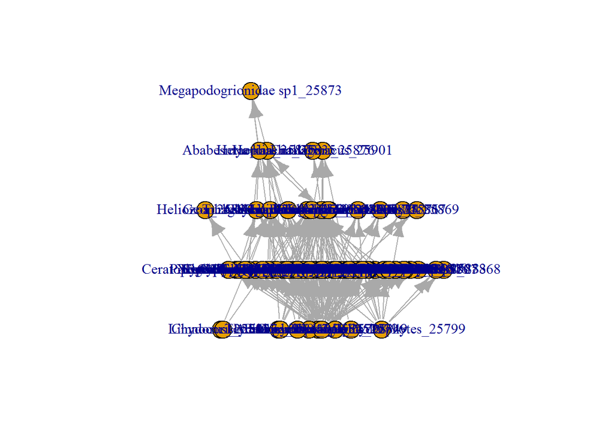

```r
foodweb<-graph_from_adjacency_matrix(mat_foodweb)
foodweb<-largest_component(foodweb)
plot(foodweb,layout=layout_as_food_web3(foodweb))
```

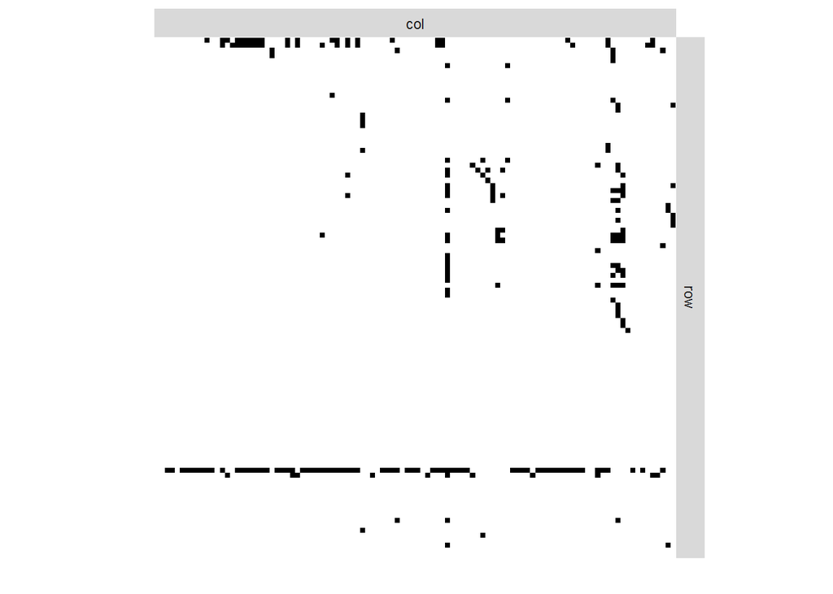

```r
plotMyMatrix(as_adj(foodweb,sparse=FALSE))
```

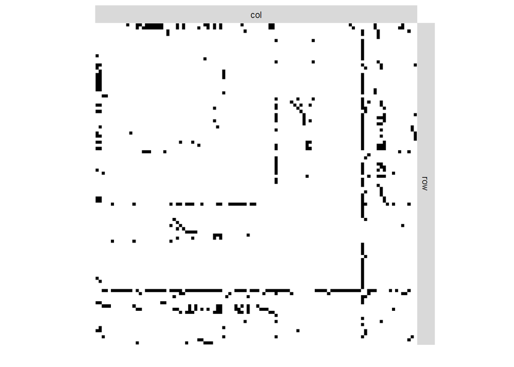

```r
undirected_foodweb<-as.undirected(foodweb)
plotMyMatrix(as_adj(undirected_foodweb,sparse=FALSE))
```

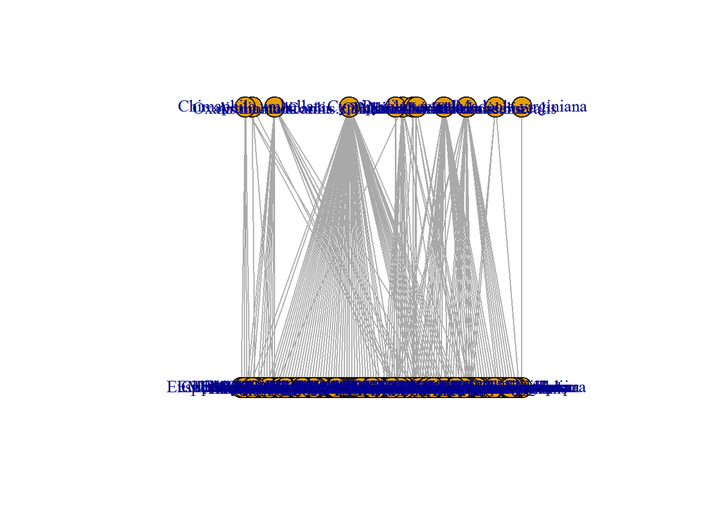

```r
pollination<-graph_from_biadjacency_matrix(mat_plantpol)
plot(pollination,layout=layout_as_bipartite)
```

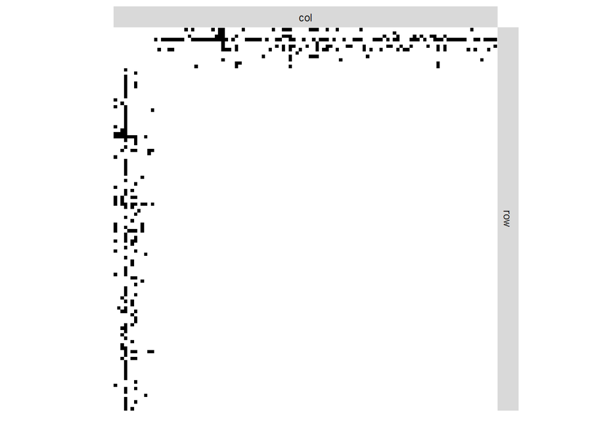

```r
plotMyMatrix(as_adj(pollination,sparse=FALSE))
```

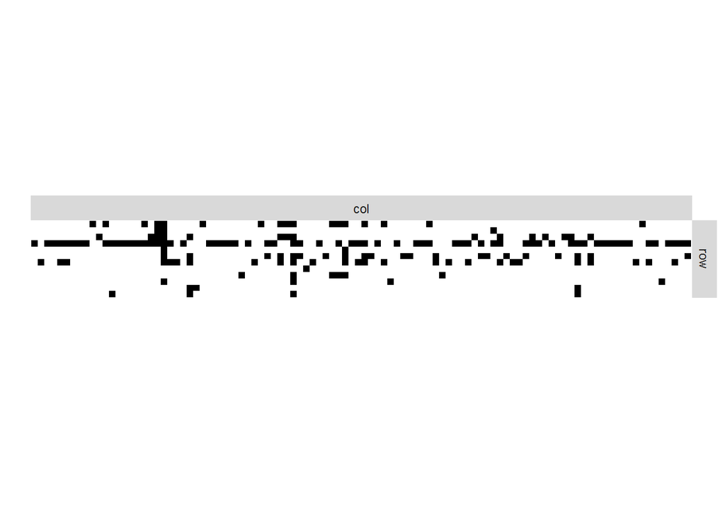

```r
plotMyMatrix(as_biadjacency_matrix(pollination,sparse=FALSE))
```

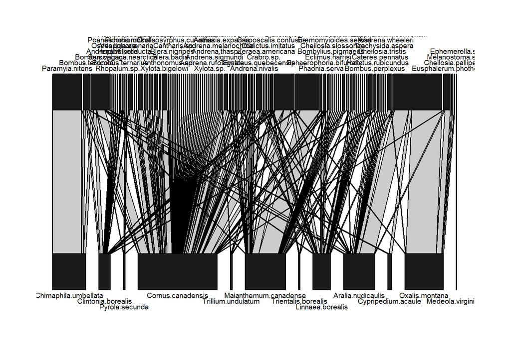

```r
pollination_bin<-graph_from_biadjacency_matrix(mat_plantpol_bin)
plotweb(mat_plantpol)
```

In the following: - foodweb is a directed binary network - undirected_foodweb is its undirected equivalent (the adjacency matrix has been made symmetric) - pollination is a weighted bipartite network - pollination_bin is its binarized version

# Advanced metrics

## Built-in metrics

The functions salvaged from `FWebs` and the `bipartite` package both yield lots of ‘’built-in automatic outputs’’, accessible through the following commands for instance:

```r
fw.metrics(list(list(mat_foodweb)))
```

```
## Computing network metrics for food web 1 of 1...
```

```
## $number_nodes
## [1] 106
##
## $number_links
## [1] 233
##
## $link_density
## [1] 2.198113
##
## $connectance
## [1] 0.02093441
##
## $compartmentalization
## [1] NaN
##
## $maximum_trophic_level
## [1] 3.84058
```

```r
networklevel(mat_plantpol)
```

```
##                       connectance                     web asymmetry                 links per species            number of compartments
##                        0.13643791                        0.78947368                        1.46491228                        2.00000000
##             compartment diversity               cluster coefficient                      modularity Q                        nestedness
##                        1.09233738                        0.08333333                        0.56737521                       10.23333209
##                              NODF               weighted nestedness                     weighted NODF                   spectral radius
##                       30.78467181                        0.66719667                       13.49547377                       72.55427745
##    interaction strength asymmetry          specialisation asymmetry                   linkage density              weighted connectance
##                        0.23565934                       -0.20755966                        9.29902902                        0.08157043
##                      Fisher alpha                 Shannon diversity              interaction evenness      Alatalo interaction evenness
##                       81.60982933                        4.11901613                        0.57933698                        0.38703061
##                                H2              number.of.species.HL              number.of.species.LL mean.number.of.shared.partners.HL
##                        0.57807328                      102.00000000                       12.00000000                        0.56105611
## mean.number.of.shared.partners.LL            cluster.coefficient.HL            cluster.coefficient.LL   weighted.cluster.coefficient.HL
##                        2.07575758                        0.29803030                        0.28659537                        0.83564121
##   weighted.cluster.coefficient.LL                  niche.overlap.HL                  niche.overlap.LL                   togetherness.HL
##                        0.17336473                        0.34762949                        0.13855758                        0.14499265
##                   togetherness.LL                        C.score.HL                        C.score.LL                        V.ratio.HL
##                        0.05157815                        0.50388420                        0.59112597                        1.54171552
##                        V.ratio.LL                    discrepancy.HL                    discrepancy.LL               extinction.slope.HL
##                       27.81509917                       71.00000000                       63.00000000                        5.84839013
##               extinction.slope.LL                     robustness.HL                     robustness.LL     functional.complementarity.HL
##                        1.54269007                        0.82379068                        0.52452619                      382.39912254
##     functional.complementarity.LL              partner.diversity.HL              partner.diversity.LL                     generality.HL
##                      338.58919107                        0.68675599                        2.17835524                        2.31225322
##                  vulnerability.LL
##                       16.28580482
```

The issue is that not all these outputs are equally useful… Let’s dissect them one by one.

## Trophic levels

Trophic levels classically correspond to the number of trophic links between a species and any basal species (primary producers) + 1. Basal species always belong to level 1 and consumers of basal species belong to species 2, etc. Complexity arises when species are omnivorous and can feed on multiple trophic levels. The package `cheddar` has methods to compute all the classic trophic levels. For instance, the first column of `foodweb_TL` gives trophic levels as computed using the ‘’shortest path’’ method (TL of a species is exactly 1+the size of the shortest path to any basal species) while the third column yields the longest trophic level (the longest path linking the focal species to any basal species).

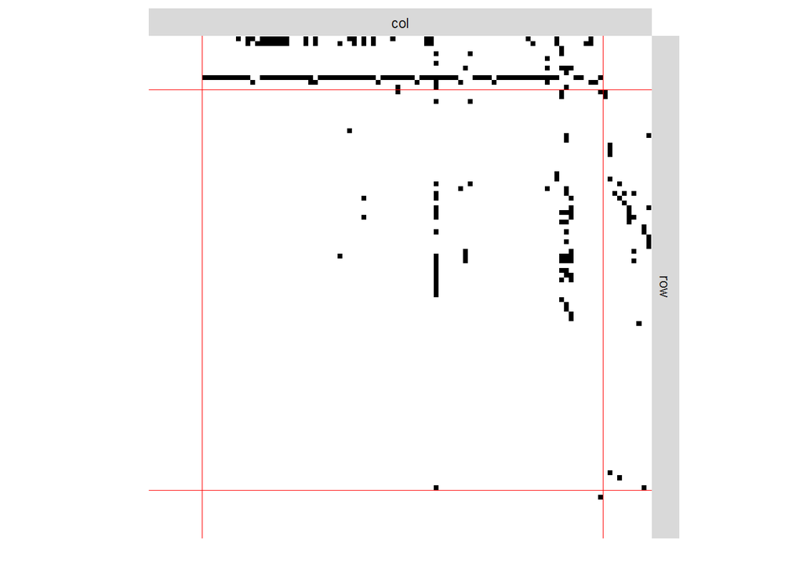

```r
foodweb_TL<-TrophicLevels(as_Community(foodweb))

plotMyMatrix(as_adj(foodweb,sparse=FALSE),clustering=list("row"=foodweb_TL[,1],"col"=foodweb_TL[,1]))
```

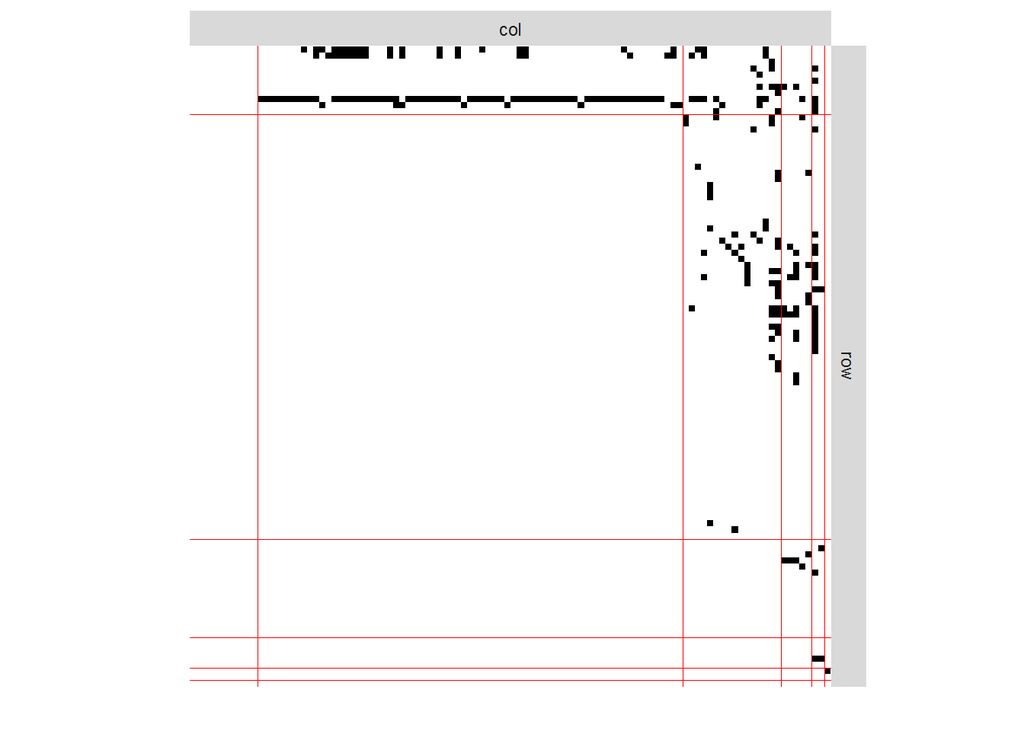

```r
plotMyMatrix(as_adj(foodweb,sparse=FALSE),clustering=list("row"=foodweb_TL[,3],"col"=foodweb_TL[,3]))
```

Another possible measure of trophic levels is the top-down measure of MacKay et al., which is based on the use of a normalized Laplacian of the graph. It yields a measure of trophic level that is maximal for apex predators and decreases according to the distance between species and the apex predators (more or less).

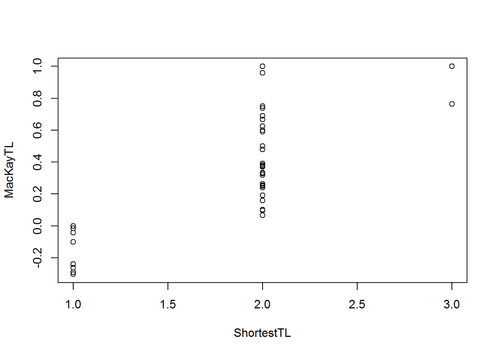

```r
tl.1<-trophic_levels(foodweb)

plot(TrophicLevels(as_Community(foodweb,"."))[,1],tl.1[,1],xlab="ShortestTL",ylab="MacKayTL")
```

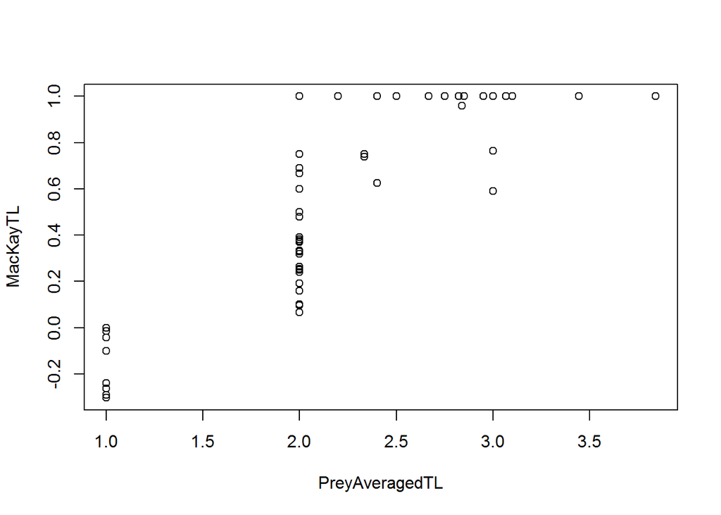

```r
plot(TrophicLevels(as_Community(foodweb,"."))[,6],tl.1[,1],xlab="PreyAveragedTL",ylab="MacKayTL")
```

These plots show the correspondence between the classic TL 1 (shortest path) and 6 (prey-averaged TL) and MacKay’s TL definition.

## Network structure

Ecological interaction networks can have non-random structures. In ecology, we tend to focus on two such structures: modularity (on the left) and nestedness (on the right).

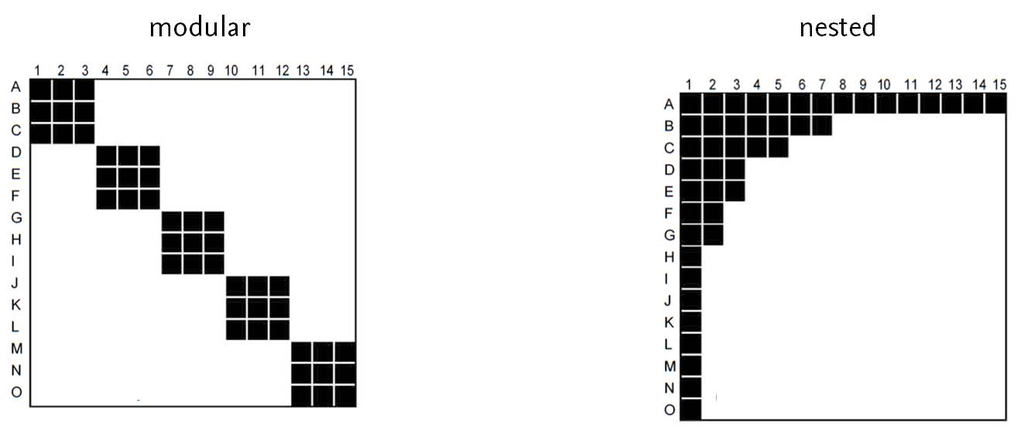

## Node specialization

In ecology, one nagging question is whether we can reliably tell the level of specialization of the different species, i.e. whether they depend on a single species or can substitute one interactor species for another one.

Blüthgen et al. (2006) proposed a metric (often noted $d_i$ or $d^\prime_i$ in its relative version) to work out the level of specialisation of a species based on weighted interactions, using the following equation:
$$d_i = \sum_j \frac{w_{ij}}{W_{i\cdot}} ln\left[ \frac{w_{ij}W_{\cdot \cdot}}{W_{i\cdot}W_{\cdot j}}\right]$$
where $w_{ij}$ is the weight of the interaction between species $i$ and $j$, $W_{i\cdot}$ is the sum of all interactions of species $i$ (row sum), $W_{\cdot j}$ is the sum of all interactions of species $j$ (column sum), and $W_{\cdot \cdot}$ is the sum of all interaction weights between all species.

The following formula yields the relative specialization score, which is always between 0 and 1:
$$d^\prime_i = \frac{d_i-d_{min}}{d_{max}-d_{min}}$$
where the $d_{min}$ and $d_{max}$ values are obtained from theoretical minimum and maximum.

The `dfun` function in the package `bipartite` does the computation of both $d$ and $d^\prime$, but the computation of $d_{min}$ is not always accurate. One can check the relationship between specialization and degree with a simple scatter plot.

```r
dfun(mat_plantpol)
```

```
## $dprime
##     Aralia.nudicaulis  Chimaphila.umbellata    Clintonia.borealis     Cornus.canadensis    Cypripedium.acaule      Linnaea.borealis
##             0.4029868             0.8734263             0.4617572             0.5573480             0.1978600             0.5606655
## Maianthemum.canadense    Medeola.virginiana        Oxalis.montana        Pyrola.secunda   Trientalis.borealis    Trillium.undulatum
##             0.6348963             1.0000000             0.7139439             0.5462431             0.7462165             0.4919476
##
## $d
##     Aralia.nudicaulis  Chimaphila.umbellata    Clintonia.borealis     Cornus.canadensis    Cypripedium.acaule      Linnaea.borealis
##             0.9987162             1.8296061             1.6615624             0.7119762             1.3358969             1.6530716
## Maianthemum.canadense    Medeola.virginiana        Oxalis.montana        Pyrola.secunda   Trientalis.borealis    Trillium.undulatum
##             1.2600139             6.3099183             1.4272914             3.0608135             4.1383474             2.8379140
##
## $dmin
##     Aralia.nudicaulis  Chimaphila.umbellata    Clintonia.borealis     Cornus.canadensis    Cypripedium.acaule      Linnaea.borealis
##             0.2416664             0.2299450             0.4001940             0.1076680             0.6219049             0.3182885
## Maianthemum.canadense    Medeola.virginiana        Oxalis.montana        Pyrola.secunda   Trientalis.borealis    Trillium.undulatum
##             0.2040323             1.6655274             0.2088886             0.8183194             0.9834566             0.8183194
##
## $dmax
##     Aralia.nudicaulis  Chimaphila.umbellata    Clintonia.borealis     Cornus.canadensis    Cypripedium.acaule      Linnaea.borealis
##              2.120264              2.061423              3.131864              1.191924              4.230477              2.699000
## Maianthemum.canadense    Medeola.virginiana        Oxalis.montana        Pyrola.secunda   Trientalis.borealis    Trillium.undulatum
##              1.867267              6.309918              1.915469              4.923624              5.211306              4.923624
```

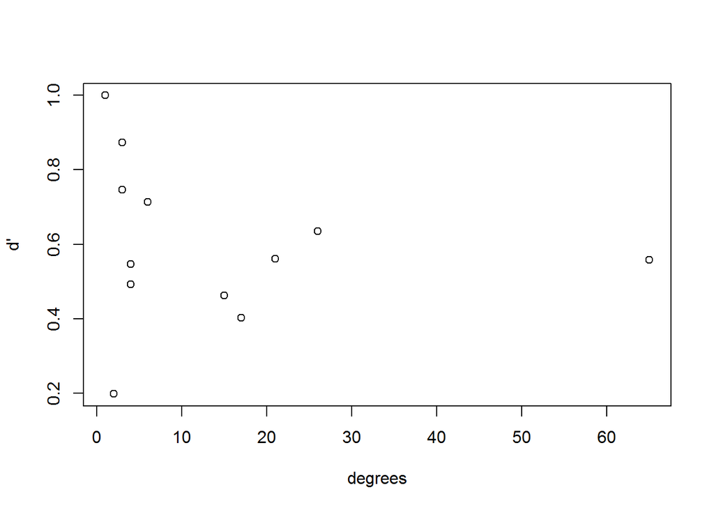

```r
plot(degree(pollination)[!V(pollination_bin)$type],dfun(mat_plantpol)$dprime,xlab="degrees",ylab="d'")
```

This function was coded for bipartite networks, but you need to transpose the bi-adjacency matrix to obtain the values of $d$ or $d^\prime$ for the other level.

```r
dfun(t(mat_plantpol))
```

```
## $dprime
##      Acmaeopsoides.rufula          Agiotes.stabilis         Ancistrocerus.sp.       Andrena.melanochroa           Andrena.miranda
##                0.00000000                0.21563785                0.07436233                0.13593241                0.04749160
##           Andrena.nivalis       Andrena.rufosignata          Andrena.sigmundi           Andrena.thaspii          Andrena.wheeleri
##                0.00000000                0.07436233                0.00000000                0.00000000                0.18138730
##          Andrena.wilkella         Andrena.w.scripta          Anthaxia.expansa            Anthonomus.sp.               Blera.badia
##                0.37904305                0.19882256                0.26144023                0.00000000                0.00000000
##             Blera.confusa            Blera.nigripes          Bombus.perplexus          Bombus.ternarius          Bombus.terricola
##                0.28139346                0.00000000                0.19070143                0.27712368                0.17343875
##             Bombus.vagans           Bombylius.major        Bombylius.pigmaeus             Cantharis.sp.      Carposcalis.confusus
##                0.15129125                0.16064599                0.13195455                0.00000000                0.38747019
##       Carposcalis.obscura          Cateres.pennatus       Celastrina.argiolus   Chalcosyrphus.curvarius   Chalcosyrphus.inarmatus
##                0.78534318                0.18138730                0.07436233                0.00000000                0.00000000
##     Chalcosyrphus.memorum       Chalcosyrphus.nigra        Cheilosia.pallipes          Cheilosia.sialia       Cheilosia.slossonae
##                0.00000000                0.07436233                0.22572129                0.07436233                0.13195455
##         Cheilosia.tristis                Crabro.sp.              Dalopius.sp.        Dialictus.cressoni        Dialictus.imitatus
##                0.18138730                0.08699553                0.00000000                0.20792957                0.22937119
##             Dialictus.sp.           Eclimus.harrisi           Ephemerella.sp.      Eremomyioides.setosa    Eudasyphora.cyanicolor
##                0.16289528                0.30481234                1.00000000                0.13195455                0.00000000
##           Eupyses.vestris      Eusphalerum.convexum       Eusphalerum.phothos           Eusphalerum.sp.        Evodinus.monticola
##                0.29446614                0.38985945                0.32822619                0.70755994                0.00000000
##        Evylaeus.divergens      Evylaeus.quebecensis           Fannia.ungulata         Halictus.confusus       Halictus.rubicundus
##                0.00000000                0.14829973                0.38962890                0.00000000                0.09710005
##         Hoplitis.producta           Hylaeus.basalis        Hylaeus.ellipticus          Hylaeus.stevensi       Judolia.montivagans
##                0.72913325                0.00000000                0.55310629                0.29446614                0.00000000
##          Lygus.refidorsus         Mallota.posticata    Melagyna.lasiophthalma           Melanostoma.sp.            Nomada.cuneata
##                0.00000000                0.02646228                0.15763329                0.22572129                0.13195455
##               Nomada.sayi            Orsodacne.atra      Orthoneura.pulchella            Osmia.lignaria             Osmia.proxima
##                0.00000000                0.00000000                0.04749160                0.37904305                0.10709229
##              Osmia.pumila           Paramyia.nitens      Parasyrphus.relictus           Passaloecus.sp.        Pegohylemyia.fugax
##                0.29446614                0.89940438                0.51915999                0.29446614                0.13195455
## Phalaenophana.pyramusalis             Phaonia.serva         Pidonia.ruficolis               Pieris.napi            Poanes.hobomok
##                0.13195455                0.21508697                0.23907334                0.00000000                0.37904305
##             Psithyrus.sp.        Pyrophaena.rosarum              Rhopalum.sp.      Sarcophaga.nearctica   Sphaerophoria.bifurcata
##                0.00000000                0.29446614                0.37904305                0.13227114                0.30083960
## Sphaerophoria.longipilosa         Sphaerophoria.sp.             Sphecodes.sp.           Syritta.pipiens            Syritta.rectus
##                0.00000000                0.19515964                0.07436233                0.00000000                0.00000000
##      Temnostoma.alternans        Temnostoma.balyras        Temnostoma.barberi     Thamnotettix.confinis         Trachysida.aspera
##                0.00000000                0.13593241                0.07436233                0.13195455                0.18138730
##         Tropidia.quadrata         Tychius.stephensi          Vespula.arenaria           Xylota.bigelowi              Xylota.hinei
```

[output cut: 120 more lines]

```
##                  6.309918                  6.309918                  5.211306                  6.309918                  5.211306
##              Osmia.pumila           Paramyia.nitens      Parasyrphus.relictus           Passaloecus.sp.        Pegohylemyia.fugax
##                  6.309918                  2.182784                  2.397895                  6.309918                  6.309918
## Phalaenophana.pyramusalis             Phaonia.serva         Pidonia.ruficolis               Pieris.napi            Poanes.hobomok
##                  6.309918                  5.211306                  4.112694                  6.309918                  6.309918
##             Psithyrus.sp.        Pyrophaena.rosarum              Rhopalum.sp.      Sarcophaga.nearctica   Sphaerophoria.bifurcata
##                  6.309918                  6.309918                  6.309918                  5.616771                  4.700480
## Sphaerophoria.longipilosa         Sphaerophoria.sp.             Sphecodes.sp.           Syritta.pipiens            Syritta.rectus
##                  6.309918                  5.211306                  5.616771                  6.309918                  6.309918
##      Temnostoma.alternans        Temnostoma.balyras        Temnostoma.barberi     Thamnotettix.confinis         Trachysida.aspera
##                  6.309918                  5.211306                  5.616771                  6.309918                  6.309918
##         Tropidia.quadrata         Tychius.stephensi          Vespula.arenaria           Xylota.bigelowi              Xylota.hinei
##                  4.923624                  5.211306                  6.309918                  4.007333                  5.211306
##                Xylota.sp.          Zeraea.americana
##                  6.309918                  5.616771
```

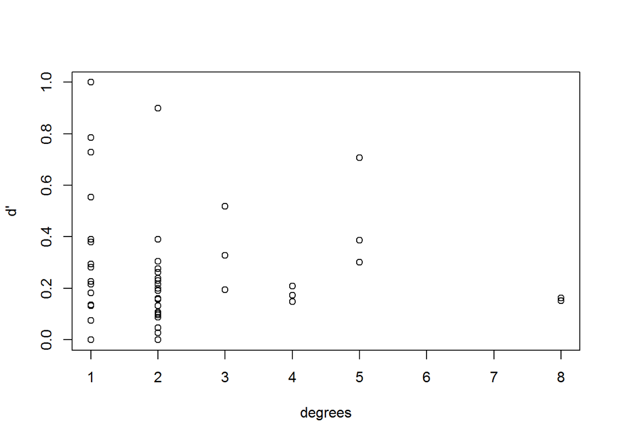

```r
plot(degree(pollination)[V(pollination_bin)$type],dfun(t(mat_plantpol))$dprime,xlab="degrees",ylab="d'")
```

In the case of unipartite directed networks / food webs, `dfun` can also be used.

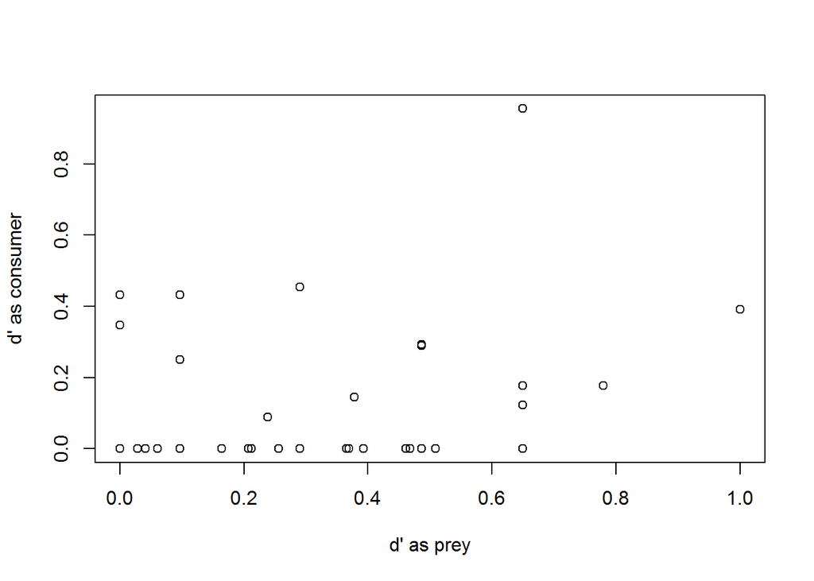

```r
foodweb_spe.res<-dfun(as_adj(foodweb,sparse=FALSE))$dprime #as resource
foodweb_spe.con<-dfun(t(as_adj(foodweb,sparse=FALSE)))$dprime #as consumer
interm_species_list<-intersect(names(foodweb_spe.res),names(foodweb_spe.con))
plot(foodweb_spe.res[which(names(foodweb_spe.res)%in%interm_species_list)],foodweb_spe.con[which(names(foodweb_spe.con)%in%interm_species_list)],xlab="d' as prey",ylab="d' as consumer")
```

## Network specialization

Blüthgen et al. (2006) also introduced a network-level metric of specialization which is based on Shannon’s entropy. The metric $H_2$ is simply the entropy of interaction weights and the relative measure $H_2^\prime$ is its opposite, scaled between 0 and 1.

```r
H2fun(mat_plantpol)
```

```
##        H2     H2min     H2max  H2uncorr
## 0.5780733 3.4320000 5.0600000 4.1190000
```

## Modularity

Modularity, as defined by Newman, is given by the following formula:
$$\begin{equation}
Q = \frac{1}{A} \sum_{i,j} \left[ a_{ij} - \frac{d_i d_j}{A}\right]\delta_{ij}
\end{equation}$$
where $A$ is the total number of connections in the network (i.e. $A = \sum_i \sum_j a_{ij}$), $d_i$ is the degree of species $i$ (i.e. $d_i = \sum_j a_{ij}$) and the $\delta_{ij}$ are dummy variables indicating whether species/nodes $i$ and $j$ are assumed to belong to the same module/community/cluster. In layman’s terms, modularity is a quantity that measures how ‘’intense’’ interactions are within modules, i.e. compares $a_{ij}$ to its expectation given the degrees of $i$ and $j$, but only taking into account edges within modules. The principle of modularity search is to look for the partitioning of nodes into communities/modules that maximizes the associated modularity score. The problem of modularity search is quite complex (NP-complete problem) and thus can be solved with different algorithms that have their pros and cons.

Modularity, in its classic form, only works for undirected networks. Three algorithms that are often used in ecology are the edge-betweenness algorithm (EB), the leading-eigenvector one (LE) and the Louvain algorithm (ML). Another useful one (and also more efficient) is simulated annealing, as implementing in `rnetcarto`.

```r
foodweb_EB.mod<-cluster_edge_betweenness(undirected_foodweb)
foodweb_LE.mod<-cluster_leading_eigen(undirected_foodweb)
foodweb_ML.mod<-cluster_louvain(undirected_foodweb)
foodweb_SA.mod<-cluster_netcarto(undirected_foodweb)
```

## Which algorithm to compute modularity?

Because there are tons of algorithms already developed to find clusters/communities/modules in networks, it is easy to get lost… Yet two papers (at least) have made our life easier by comparing all these algorithms, bot for unipartite networks (Yang et al. 2016) and bipartite networks (Leger et al. 2015).

## Plotting modularity

Here is a comparison of modules as obtained through the four algorithms used before.

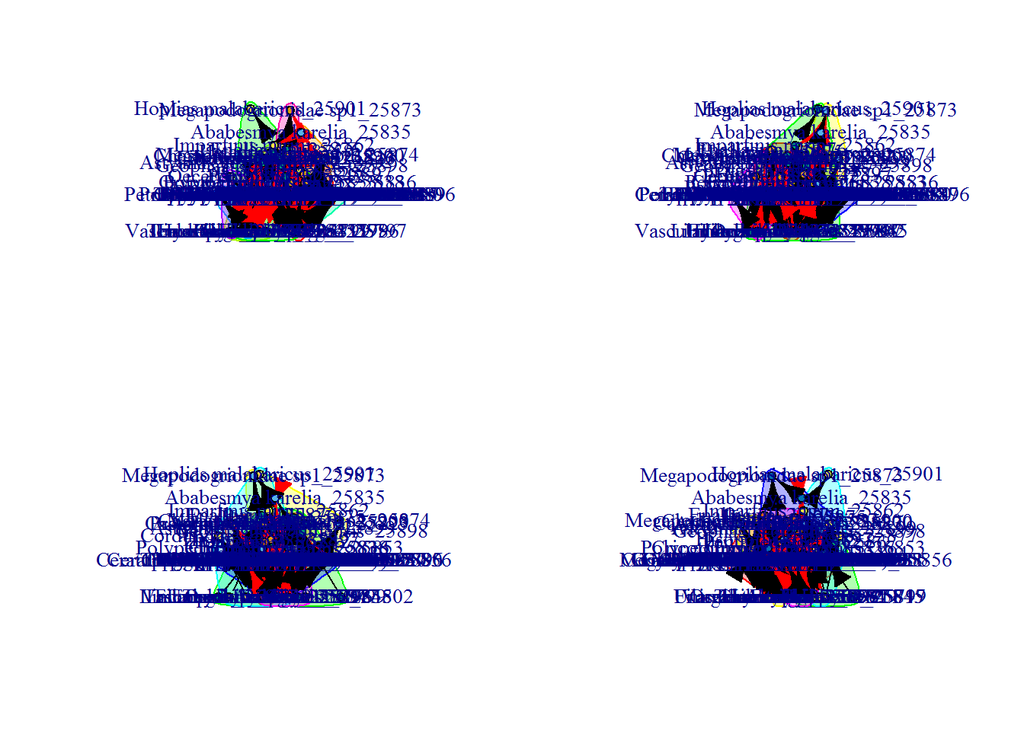

```r
par(mfrow=c(2,2))
plot(foodweb_EB.mod,foodweb,layout = layout_as_food_web(foodweb))
plot(foodweb_LE.mod,foodweb,layout = layout_as_food_web(foodweb))
plot(foodweb_ML.mod,foodweb,layout = layout_as_food_web(foodweb))
plot(foodweb_SA.mod,foodweb,layout = layout_as_food_web(foodweb))
```

It is also possible to plot the modules using the ‘’matrix’’ visualization of networks.

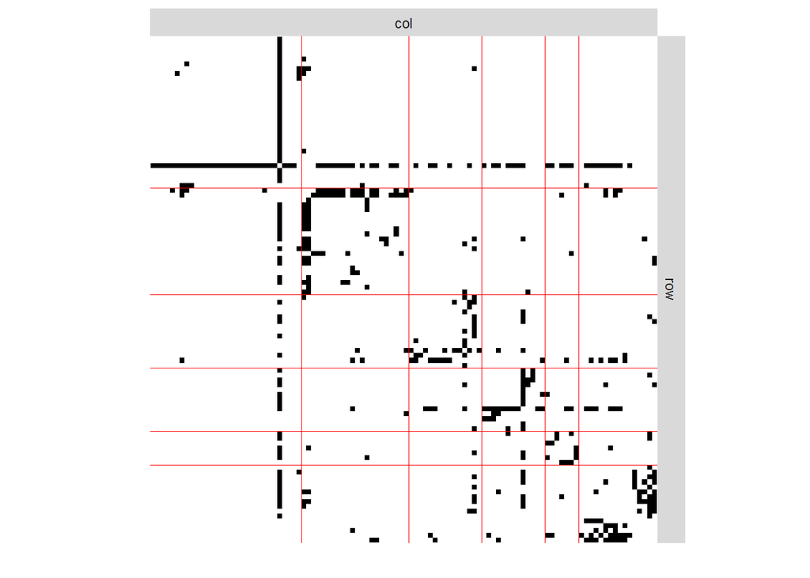

```r
plotMyMatrix(as_adj(undirected_foodweb,sparse=FALSE),clustering=list("row"=foodweb_SA.mod$membership,"col"=foodweb_SA.mod$membership))
```

## Comparing modules from the different algorithms

For the sake of visualizing whether the modules obtained with the different algorithms correspond, we can make use of alluvial plots.

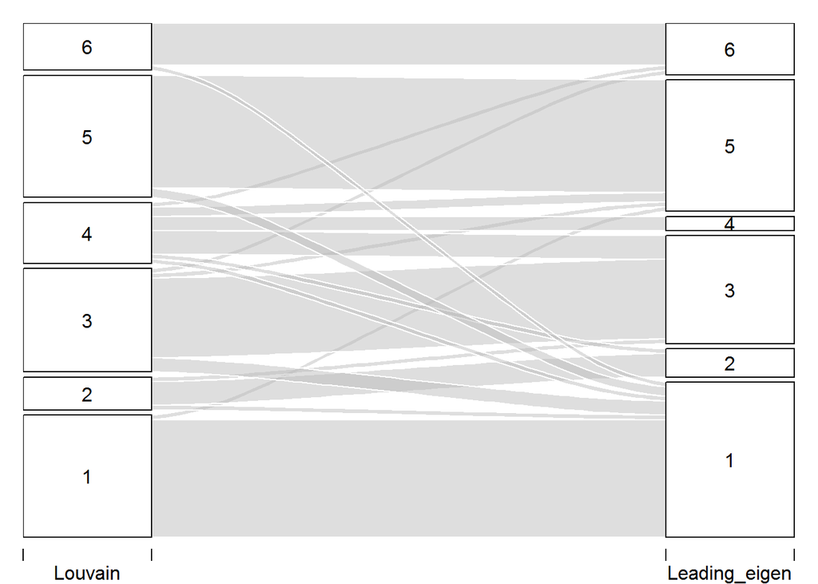

```r
make_alluvial_2(foodweb_ML.mod$membership,foodweb_LE.mod$membership,"Louvain","Leading_eigen")
```

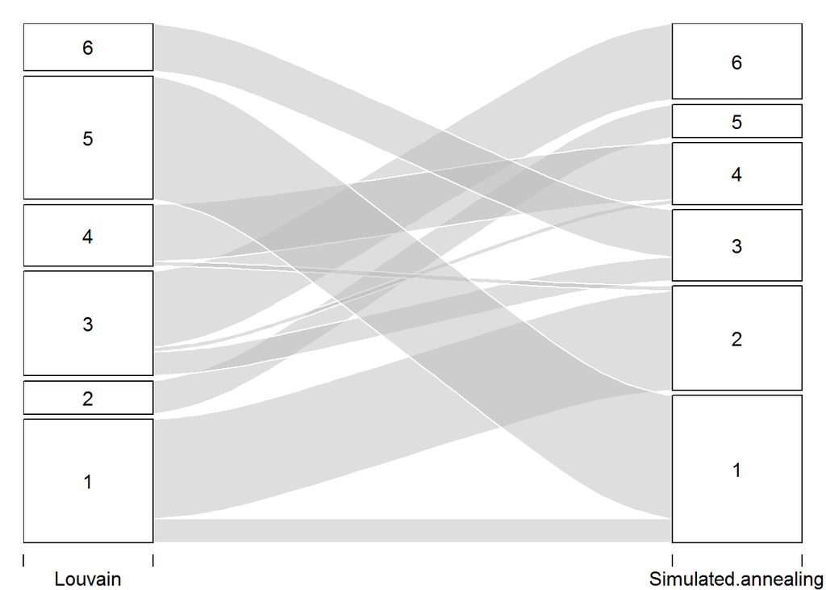

```r
make_alluvial_2(foodweb_ML.mod$membership,foodweb_SA.mod$membership,"Louvain","Simulated annealing")
```

## Modularity on bipartite network

Modularity work as easily on bipartite networks as on unipartite ones. However, the representation of the modules is more useful when done on the bi-adjacency matrix.

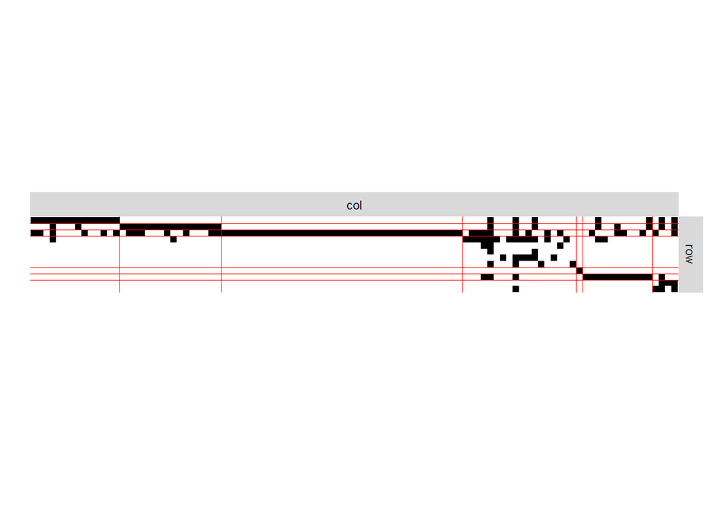

```r
pollination_SA.mod<-cluster_netcarto(pollination_bin)

plotMyMatrix(mat_plantpol_bin,clustering=list("row"=pollination_SA.mod$membership[!V(pollination_bin)$type],"col"=pollination_SA.mod$membership[V(pollination_bin)$type]))
```

## Spectral clustering

A convenient alternative algorithm to find clusters within a network is spectral clustering. The idea of spectral clustering is to make use of the Laplacian matrix $L$ of the graph, given by:
$$L = D - A$$
where $D$ is the diagonal matrix of nodes’ degrees and $A$ is the adjacency matrix.

The Laplacian matrix has interesting properties, the best of all being that the number of zeros among its eigenvalues yield the number of components of the graph (one 0 means there is a single connected component, two zeros means the network is split in two disconnected components, etc.). The eigenvectors associated the zero eigenvalues can inform on the membership of nodes to the different components.

The heuristics of the spectral clustering is to use the eigenvectors associated with the set of small non-zero eigenvalues of $L$ to deduce the ‘’almost components’’ of the graph. To do so, one chooses a number of no-zero eigenvalues to keep and then the algorithm uses the associated eigenvector to find the groups through a K-means algorithm on the space obtained with these eigenvectors.

The function `laplacian_spectral_gap` computes the ‘’spectral gap’’ plot and tries to find the optimum number of clusters.

```r
foodweb_SG<-laplacian_spectral_gap(undirected_foodweb)
```

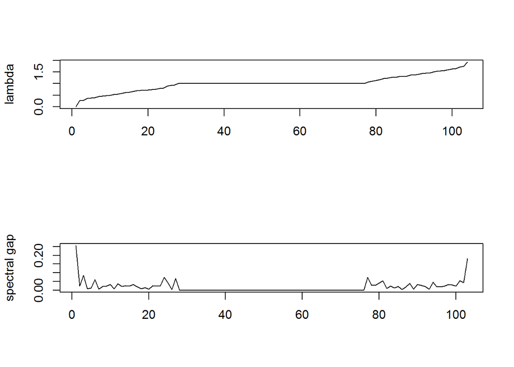

```r
foodweb_SG$optim_n
```

```
## [1] 3
```

Once we know how many clusters we are looking for, we can compute the spectral clustering.

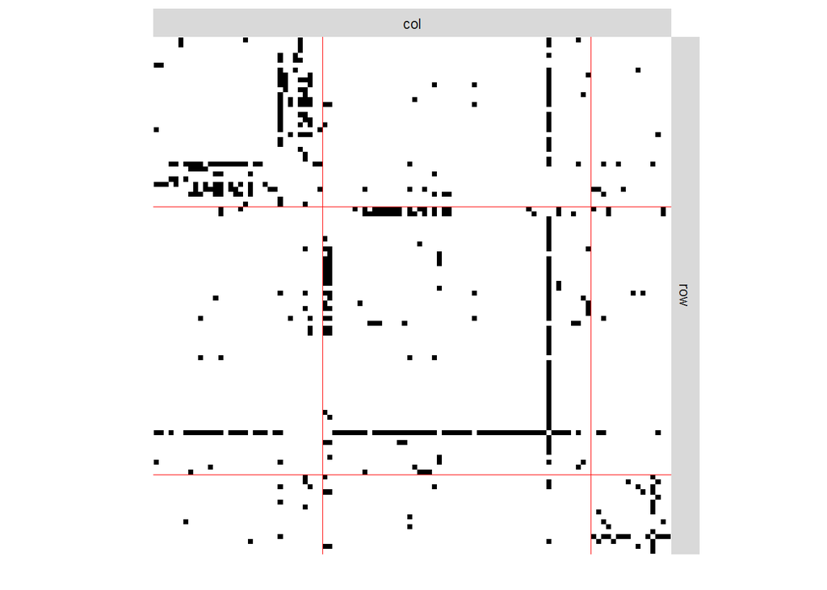

```r
foodweb_SC<-spectral_clustering(undirected_foodweb,foodweb_SG$optim_n)
plotMyMatrix(as_adj(undirected_foodweb,sparse=FALSE),clustering=list("row"=foodweb_SC,"col"=foodweb_SC))
```

```r
modularity(undirected_foodweb,foodweb_SC)
```

```
## [1] 0.3296616
```

In passing, we note that the modularity of the spectral clustering is not so bad.

## Comparison between modules and spectral clusters

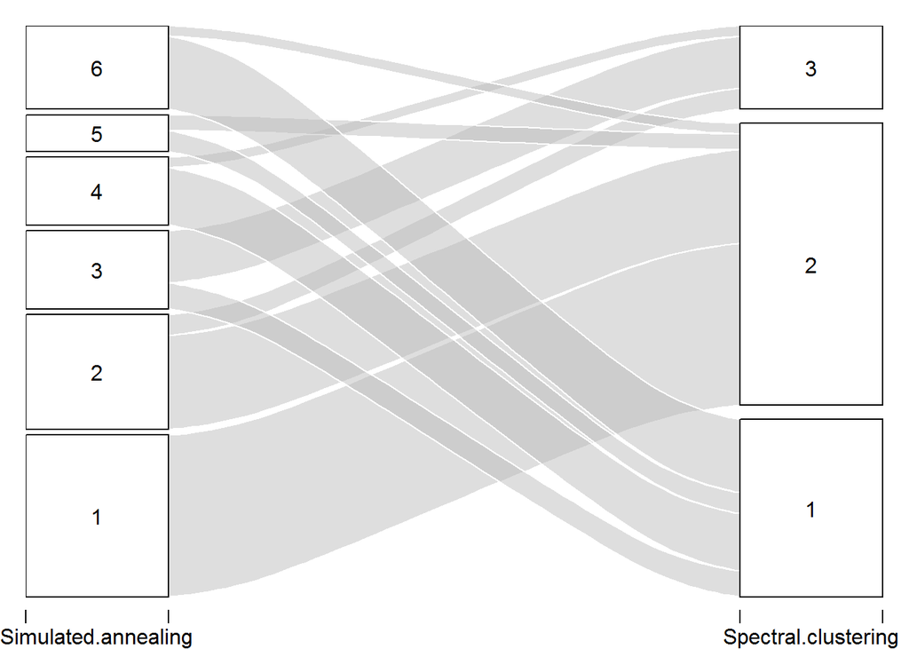

```r
make_alluvial_2(foodweb_SA.mod$membership,foodweb_SC,"Simulated annealing","Spectral clustering")
```

## Nestedness

The idea of nestedness is to measure the tendency for specialists to only interact with a subsample of the interactors of generalists. In other words, a network would be said “non-nested” only when specialists would interact more likely with specialists than with generalists.

Several indices have been developed over the years. Navigating their complexity is the purpose of the synthesis written by Podani and Schmera (2012).

The package bipartite proposes some methods to do this (partly borrowed from the package vegan), in the function `nested`.

```r
pollination_nestdness<-nested(mat_plantpol, method = "ALL", rescale=TRUE, normalised=TRUE)
```

Another option is to use the various functions directly from vegan:

```r
nestednodf(mat_plantpol)
```

```
## N columns  : 30.72672
## N rows     : 35.30757
## NODF       : 30.78467
## Matrix fill: 0.1364379
```

```r
nestednodf(mat_plantpol,weighted=TRUE)
```

```
## N columns  : 13.49511
## N rows     : 13.52354
## NODF       : 13.49547
## Matrix fill: 0.1364379
```

```r
nestednodf(mat_plantpol,weighted=TRUE,wbinary=T)
```

```
## N columns  : 25.53355
## N rows     : 25.85196
## NODF       : 25.53758
## Matrix fill: 0.1364379
```

```r
nestednodf(mat_plantpol_bin)
```

```
## N columns  : 30.72672
## N rows     : 35.30757
## NODF       : 30.78467
## Matrix fill: 0.1364379
```

```r
nestednodf(mat_plantpol_bin,weighted=TRUE)
```

```
## N columns  : 0
## N rows     : 0
## NODF       : 0
## Matrix fill: 0.1364379
```

```r
nestednodf(mat_plantpol_bin,weighted=TRUE,wbinary=T)
```

```
## N columns  : 30.72672
## N rows     : 35.30757
## NODF       : 30.78467
## Matrix fill: 0.1364379
```

Recent research seems to indicate that the concept of nestedness is not really fruitful for a variety of reasons: - it seems to be very strongly linked to connectance; - the diversity of nestedness indices tend to obfuscate its meaning (results reported show more about the index than about the concept); - these different indices can yield very different results when applied to the same dataset; - in the classic case of power law distributions of degrees, the nestedness scores tend to be completely detrmined by the exponent of the power law; - finally, when putting the common datasets in the right matrix ensemble (i.e. using correct null models to sample similar matrices), reported nestedness values seem to be completely expected.

## Robustness to secondary extinctions

The general idea is to assume that when a species is removed from a network, the species interacting with it could go extinct (secondary extinction). Robustness analysis then consists in assessing how many species are lost when R species are removed. The most used indicator of robustness is the R50 which is the percentage of species on needs to remove from a web to lose 50% of its species.

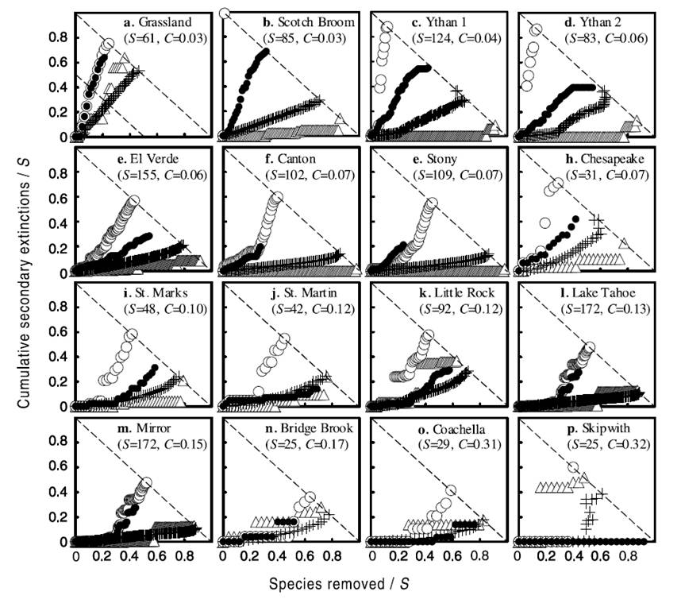

In the paper of J. Dunne and collaborators, they used examples based on a variety of datasets. The basic rule then is that a species go extinct when it loses all its prey items (except itself if it is cannibalistic). One can obtain different scenarios based on how removed species are chosen (intentionality: how strongly the species’ degree changes its probability of being drawn randomly as the next one to be removed).

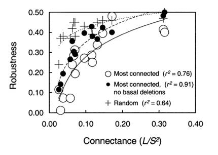

We can first try a robustness analysis on a virtual dataset, using `FWebs` (or the functions in `crutch_functions.R`). We will use the “niche model” to generate a virtual food web.

The plot yields the value of the R50 as a function of intentionality, which is a proxy for how strongly species removals target species based on their degree.

```
## Iteration 1
```

```
## Iteration 2
```

```
## Iteration 3
```

```
## Iteration 4
```

```
## Iteration 5
```

```
## Iteration 6
```

```
## Iteration 7
```

```
## Iteration 8
```

```
## Iteration 9
```

```
## Iteration 10
```

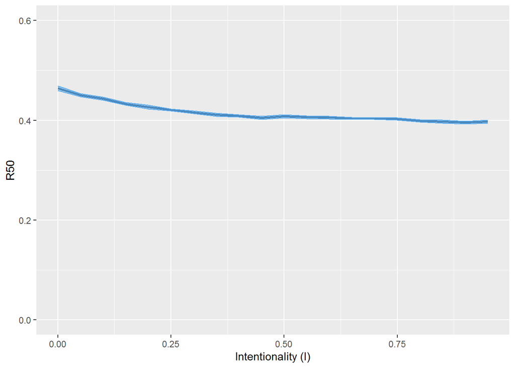

```r
niche<-niche_matrix(0.2,200)
m<-niche$matrix
netw<-graph_from_adjacency_matrix(m,mode="directed")
V(netw)$name<-paste0("x",as.character(1:200))

i_index <- seq(from = 0, to = 0.95, by =0.05)
prob_exp<-exponent.removal(degree(netw,mode="out"), i_index)
netw_iterate_deg<-iterate(fw_to_attack=netw, prob_exp, alpha1=50, iter=10, i_index, plot = TRUE)
```

We can also try it on the real food web data:

```
## Iteration 1
```

```
## Iteration 2
```

```
## Iteration 3
```

```
## Iteration 4
```

```
## Iteration 5
```

```
## Iteration 6
```

```
## Iteration 7
```

```
## Iteration 8
```

```
## Iteration 9
```

```
## Iteration 10
```

```
## Iteration 11
```

```
## Iteration 12
```

```
## Iteration 13
```

```
## Iteration 14
```

```
## Iteration 15
```

```
## Iteration 16
```

```
## Iteration 17
```

```
## Iteration 18
```

```
## Iteration 19
```

```
## Iteration 20
```

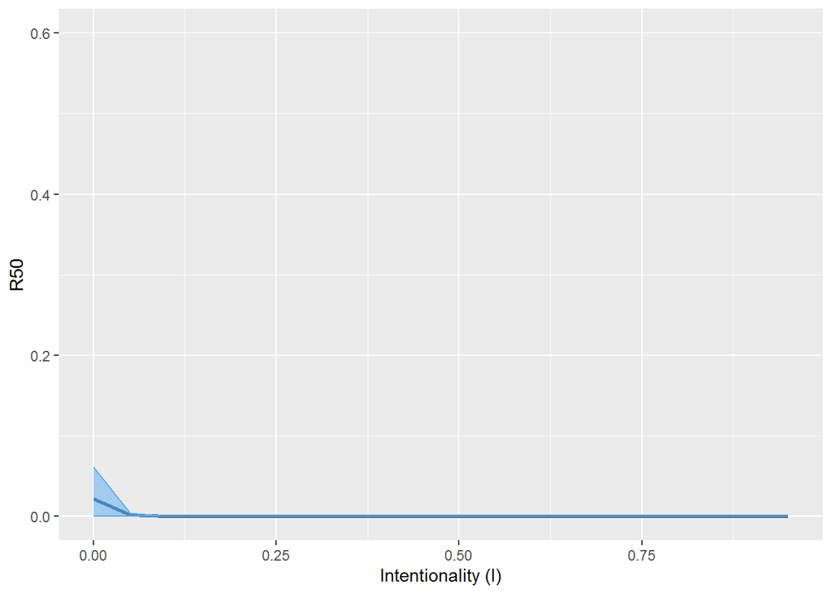

```r
prob_exp_FW<-exponent.removal(degree(foodweb,mode="out"), i_index)
fw_iterate_deg<-iterate(fw_to_attack=foodweb, prob_exp_FW, alpha1=50, iter=20, i_index, plot = TRUE)
```

```
## Iteration 1
```

```
## Iteration 2
```

```
## Iteration 3
```

```
## Iteration 4
```

```
## Iteration 5
```

```
## Iteration 6
```

```
## Iteration 7
```

```
## Iteration 8
```

```
## Iteration 9
```

```
## Iteration 10
```

```
## Iteration 11
```

```
## Iteration 12
```

```
## Iteration 13
```

```
## Iteration 14
```

```
## Iteration 15
```

```
## Iteration 16
```

```
## Iteration 17
```

```
## Iteration 18
```

```
## Iteration 19
```

```
## Iteration 20
```

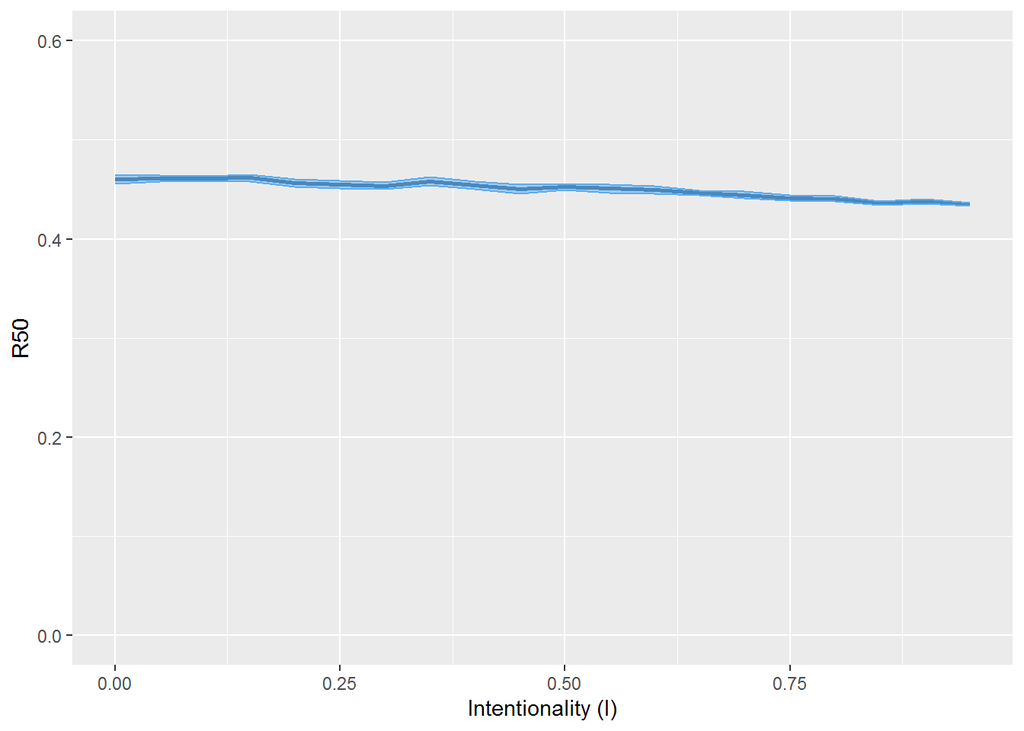

```r
prob_exp<-exponent.removal(trophic_levels(netw), i_index)
netw_iterate_TL<-iterate(fw_to_attack=netw, prob_exp, alpha1=50, iter=20, i_index, plot = TRUE)
```

```
## Iteration 1
```

```
## Iteration 2
```

```
## Iteration 3
```

```
## Iteration 4
```

```
## Iteration 5
```

```
## Iteration 6
```

```
## Iteration 7
```

```
## Iteration 8
```

```
## Iteration 9
```

```
## Iteration 10
```

```
## Iteration 11
```

```
## Iteration 12
```

```
## Iteration 13
```

```
## Iteration 14
```

```
## Iteration 15
```

```
## Iteration 16
```

```
## Iteration 17
```

```
## Iteration 18
```

```
## Iteration 19
```

```
## Iteration 20
```

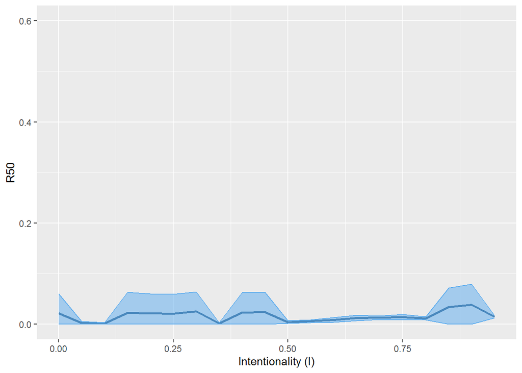

```r
foodweb_TL<-as.data.frame(TrophicLevels(as_Community(foodweb)))
prob_exp_FW<-exponent.removal(foodweb_TL$LongestTL, i_index)
fw_iterate_TL<-iterate(fw_to_attack=foodweb, prob_exp_FW, alpha1=50, iter=20, i_index, plot = TRUE)
```

## Beta diversity of networks

Ohlmann et al. developed a measure of the “beta diversity” of nodes and links among networks that share some nodes. For nodes, this amounts to the classic beta diversity of communities. For links, two measures are possible, based on the following formula:
$$L_{ij} = \pi_{ij}p_ip_j$$
where - $L_{ij}$ is the relative weight of the link between species $i$ and $j$, - $p_i$ is the relative abundance of species $i^$, - $\pi_{ij}$ is the probability of interaction between species $i$ and $j$j. The beta diversity of the $p$’s corresponds to the beta diversity of nodes (community diversity), while the beta diversity of either $L_{ij}$ or $\pi_{ij}$ provides a measure of link diversity among networks.

The functions are implement in package `econetwork`. We test it on four networks of the same 60 species.

```r
gList <- c()
for(i in 1:4){
  graphLocal <- sample_gnp(60, 0.1, directed=TRUE)
  V(graphLocal)$name <- as.character(1:60)
  gList <- c(gList, list(graphLocal))
}
names(gList) <- c("A","B","C","D")

disPairwise(gList, type='P')
```

[output not shown]

```
##   A B C
## B 0
## C 0 0
## D 0 0 0
```

```r
disPairwise(gList, type='L')
```

[output not shown]

```
##           A         B         C
## B 0.8912001
## C 0.8771519 0.9100341
## D 0.8768809 0.8770819 0.8930309
```

```r
disPairwise(gList, type='Pi')
```

[output not shown]

```
##           A         B         C
## B 0.8912001
## C 0.8771519 0.9100341
## D 0.8768809 0.8770819 0.8930309
```

As expected, the dissimilarity/distance between node sets is 0, but the distance among edge sets is greater than 0.

# Network models

Statistics on networks are hard to test because everything depends on everything else. In order to test statistics, we need to construct models. These are generally classified in two types: - null models, which correspond to algorithmic models shuffling the initial network to obtain a series of networks that obey some constraints (e.g. same sequence of degrees of the nodes) - generative models, which provide a network based on a few parameters and some working hypotheses (e.g. all connections are equally likely and their probability is known)

Among generative models, some (but not all) are probabilistic (i.e. can be fitted), which clearly opens the door to the elaboration of statistical tests in the classic sense (testing whether the working hypothesis of the model holds).

The other generative models (e.g. preferential attachment) and all null models can be used to re-simulate the network in order to obtain the p-value corresponding to the occurrence of the statistic value under the hypothesis represented by the generative or null model.

## How to make a food web form an undirected unipartite graph?

Before tackling models per se, one important step is to be able to convert any undirected unipartite network into a directed network that can be thought of as a food web. The main difficulties are that randomly orienting the links is likely - to cause cycles (which in principle do not exist in food webs), and - not to have a few species that feed on no one else (the “basal” level).

The `make_food_web_from_undirected` function tries to cope with this two difficulties. It asks for an undirected graph and a number of basal species. Then it proceeds in two steps:

1. it colours the graph to find one color that has at least as many nodes as the basal set, and then it assigns the “basal species” into this colour;
2. it orients the graph using a breadth-first search (see the following figure).

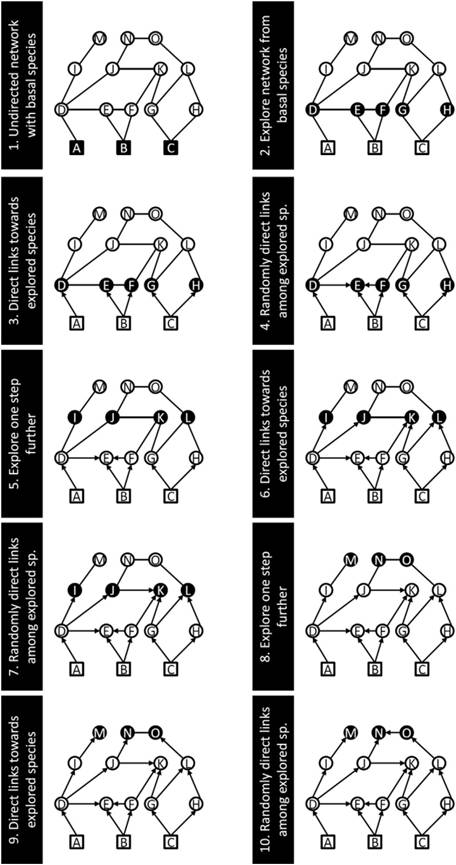

## The configuration model

One of the most useful and simplest null model is the configuration model. Under this model, edges are randomly reattached to other nodes such that all nodes keep their degrees. This behaves effectively as if all nodes were attached to half-edges which were randomly paired until the resulting network yields no self-link and no double link.

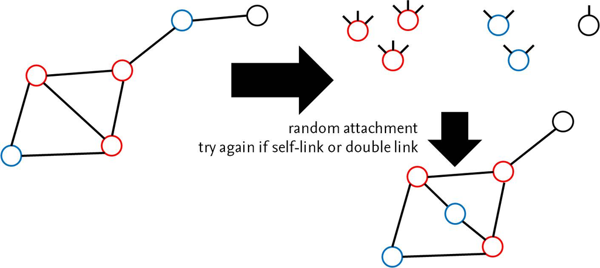

### Generate configurations for an undirected unipartite network

Here is an example to generate configurations starting with a random graph (Erdos-Rényi model).

```r
net<-sample_gnp(50,0.2, directed=FALSE)
sample.config.undirected<-lapply(1:100,function(x) sample_degseq(degree(net), method = "vl"))
length(sample.config.undirected)
```

```
## [1] 100
```

The function `config_VL` (in the source file) does that automatically from the input network or from its adjacency matrix.

```r
alt.config<-config_VL(net,100)
```

```
## [1] "unipartite graph detected"
```

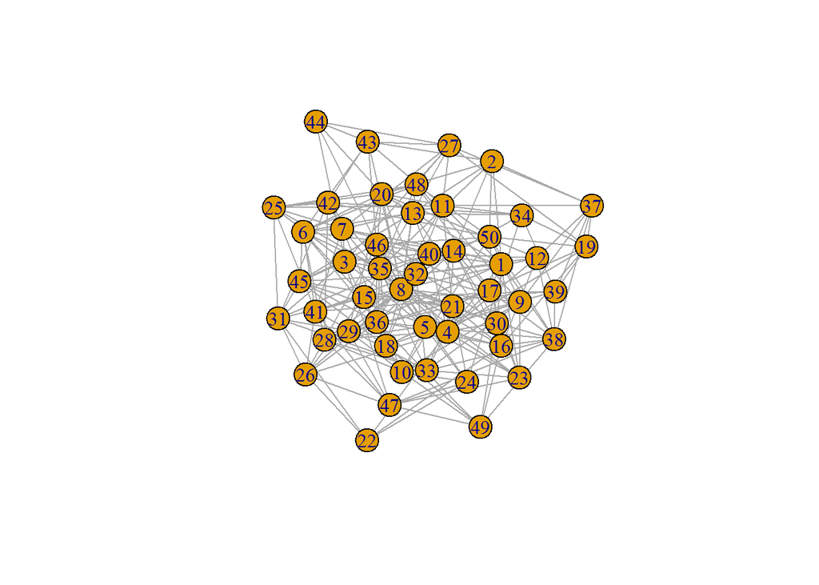

```r
plot(alt.config[[42]])
```